# WGU D502 Analysis

Contained below is code and analysis of all cleaning processes, exploratory data analysis (EDA) methods, visualizations, and model implementations for the D502 Data Analytics Capstone.

```python
import pandas as pd
import openmeteo_requests
import requests_cache
import numpy as np
from retry_requests import retry
import matplotlib.pyplot as plt
import matplotlib.dates as mdates
import seaborn as sns
import xgboost as xgb
from sklearn.model_selection import train_test_split
from sklearn.metrics import root_mean_squared_error, mean_squared_error, r2_score
from sklearn.model_selection import TimeSeriesSplit
import itertools
import scipy.stats as stats

!pip install openmeteo-requests
!pip install requests-cache retry-requests numpy pandas
!pip install xgboost
```

## Introduction

South Korea, home to nearly 52 million people, has grappled with air pollution for decades. Despite the modest improvement in air quality over time, the issue continues to result in health problems, which increase healthcare costs, hurt worker productivity, and disrupt entire sectors of the economy. These pollutants originate both domestically, from fossil fuel combustion, and internationally, with a significant portion of fine dust pollution blowing in from China. The primary pollutant is PM2.5, a type of particulate matter less than 2.5 micrometers in diameter and often more hazardous to human health due to the ease with which it enters the lungs.

Given the economic and health impacts of poor air quality, it is essential to build more robust models that predict the PM2.5 levels of a given day based on recent and historical trends in temperature and precipitation. In other words, through understanding meterological data, South Korea can better anticipate periods of heightened pollutant activity, protecting sensitive populations the health risk of breathing unclean air while reducing the broader economic burden posed by pollution.

Our primary question is: to what extent do daily temperature and precipitation indicate daily and yearly trends in PM2.5 values across South Korea? To work up to this central question, we will first conduct EDA and later experiment with modeling. For regional insights, we will focus on three different areas:

- Gwanak-gu, a district in Seoul (northwest, Seoul/Gyeonggi Province)
- Hyeoksin-dong, a neighborhood in Jeonju (southwest, North Jeolla Province)
- Cheongnim-dong, a neighborhood in Pohang (mid-east, North Gyeongsang Province)

This will allow us to understand geographical variations in our data.

## Data Import and Cleaning

#### **Dataset 1**

Our first dataset, "South Korean Pollution," originates from Kaggle, uploaded by Caleb Reigada and originally obtained from https://www.airkorea.or.kr/web/. It contains the following variables:

- date - date of measurement
- pm25 - fine particulate matter (PM2.5) (µg/m3)
- pm10 - fine particulate matter (PM10) (µg/m3)
- o3 - Ozone (O3) (µg/m3)
- no2 - Nitrogen Dioxide (NO2) (ppm)
- so2 - Sulfur Dioxide (SO2) (ppm)
- co - Carbon Monoxide (CO) (ppm)
- Lat - Latitude where measurement was taken
- Long - Longitude where measurement was taken
- City - City where measurement was taken
- District - District where measurement was taken
- Country - Country where measurement was taken

```python
df1 = pd.read_csv("south-korean-pollution-data.csv", index_col=0)
df1.head()
```

|  | date | pm25 | pm10 | o3 | no2 | so2 | co | Lat | Long | City | District | Country |
| --- | --- | --- | --- | --- | --- | --- | --- | --- | --- | --- | --- | --- |
| 0 | 2022/2/1 | 112 | 31 | 35 | 2 | 1 | 4 | 38.2089 | 127.9495 | Bangsan-Myeon | Gangwon | South Korea |
| 1 | 2022/2/2 | 92 | 21 | 35 | 2 | 1 | 0 | 38.2089 | 127.9495 | Bangsan-Myeon | Gangwon | South Korea |
| 2 | 2022/2/3 | 60 | 20 | 35 | 1 | 1 | 4 | 38.2089 | 127.9495 | Bangsan-Myeon | Gangwon | South Korea |
| 3 | 2022/2/4 | 51 | 27 | 33 | 1 | 1 | 4 | 38.2089 | 127.9495 | Bangsan-Myeon | Gangwon | South Korea |
| 4 | 2022/2/5 | 57 | 24 | 27 | 2 | 1 | 5 | 38.2089 | 127.9495 | Bangsan-Myeon | Gangwon | South Korea |

First, let's ensure all variables are encoded properly.

```python
df1.dtypes
```

```
date         object
pm25          int64
pm10          int64
o3            int64
no2           int64
so2           int64
co            int64
Lat         float64
Long        float64
City         object
District     object
Country      object
dtype: object
```

Despite representing dates, the "date" variable is encoded as an object/string. To work with datetime operations more efficiently, this should be recoded as a datetime object.

```python
df1['date'] = pd.to_datetime(df1['date'], format='%Y/%m/%d')
df1.dtypes
```

```
date        datetime64[ns]
pm25                 int64
pm10                 int64
o3                   int64
no2                  int64
so2                  int64
co                   int64
Lat                float64
Long               float64
City                object
District            object
Country             object
dtype: object
```

In addition, it is typically more standard to have the location/identifier variables appear to the left of the attribute variables. These columns can be rearranged easily. We can also drop the Country column.

```python
df1 = df1[['date', 'Lat', 'Long', 'City', 'District',
           'pm25', 'pm10', 'o3', 'no2', 'so2', 'co']]
df1.head()
```

|  | date | Lat | Long | City | District | pm25 | pm10 | o3 | no2 | so2 | co |
| --- | --- | --- | --- | --- | --- | --- | --- | --- | --- | --- | --- |
| 0 | 2022-02-01 | 38.2089 | 127.9495 | Bangsan-Myeon | Gangwon | 112 | 31 | 35 | 2 | 1 | 4 |
| 1 | 2022-02-02 | 38.2089 | 127.9495 | Bangsan-Myeon | Gangwon | 92 | 21 | 35 | 2 | 1 | 0 |
| 2 | 2022-02-03 | 38.2089 | 127.9495 | Bangsan-Myeon | Gangwon | 60 | 20 | 35 | 1 | 1 | 4 |
| 3 | 2022-02-04 | 38.2089 | 127.9495 | Bangsan-Myeon | Gangwon | 51 | 27 | 33 | 1 | 1 | 4 |
| 4 | 2022-02-05 | 38.2089 | 127.9495 | Bangsan-Myeon | Gangwon | 57 | 24 | 27 | 2 | 1 | 5 |

#### Dataset 2

Our second dataset comes from Open-Meteo's Weather API, with the following variables:

- date - date and time
- temperature_2m_mean - mean daily air temperature at 2m above ground
- precipitation sum - sum of daily precipitation
- location - location (gu = "district", dong = "neighborhood")

Three separate datasets will be imported, one for each location. Once the data is cleaned, we will combine all three datasets with Dataset 1.

```python
cache_session = requests_cache.CachedSession('.cache', expire_after=-1)
retry_session = retry(cache_session, retries=5, backoff_factor=0.2)
openmeteo = openmeteo_requests.Client(session=retry_session)

locations = {
    "Gwanak-Gu": (37.48, 126.95),
    "Hyeoksin-Dong": (35.84, 127.06),
    "Cheongnim-Dong": (36.00, 129.41)
}

base_params = {
    "start_date": "2015-01-02",
    "end_date": "2022-01-01",
    "daily": ["temperature_2m_mean", "precipitation_sum"],
    "timezone": "Asia/Tokyo"
}

dfs = []

for name, (lat, lon) in locations.items():
    params = base_params.copy()
    params["latitude"] = lat
    params["longitude"] = lon

    responses = openmeteo.weather_api("https://archive-api.open-meteo.com/v1/archive", params=params)
    response = responses[0]

    daily = response.Daily()
    daily_temperature_2m_mean = daily.Variables(0).ValuesAsNumpy()
    daily_precipitation_sum = daily.Variables(1).ValuesAsNumpy()

    daily_data = {
        "date": pd.date_range(
            start=pd.to_datetime(daily.Time(), unit="s", utc=True),
            end=pd.to_datetime(daily.TimeEnd(), unit="s", utc=True),
            freq=pd.Timedelta(seconds=daily.Interval()),
            inclusive="left"
        ),
        "temperature_2m_mean": daily_temperature_2m_mean,
        "precipitation_sum": daily_precipitation_sum,
        "location": name
    }

    df = pd.DataFrame(daily_data)
    dfs.append(df)

df2_gwanak = dfs[0]
df2_hyeoksin = dfs[1]
df2_cheongnim = dfs[2]

df2_gwanak.head()
```

|  | date | temperature_2m_mean | precipitation_sum | location |
| --- | --- | --- | --- | --- |
| 0 | 2015-01-01 15:00:00+00:00 | -5.139250 | 0.0 | Gwanak-Gu |
| 1 | 2015-01-02 15:00:00+00:00 | -3.555917 | 0.0 | Gwanak-Gu |
| 2 | 2015-01-03 15:00:00+00:00 | 1.592000 | 0.0 | Gwanak-Gu |
| 3 | 2015-01-04 15:00:00+00:00 | 2.162833 | 1.0 | Gwanak-Gu |
| 4 | 2015-01-05 15:00:00+00:00 | -3.153833 | 3.0 | Gwanak-Gu |

Let's check data types:

```python
df2_gwanak.dtypes
```

```
date                   datetime64[ns, UTC]
temperature_2m_mean                float32
precipitation_sum                  float32
location                            object
dtype: object
```

The formats are correct, but the time component of the datetime object is unnecessary.

```python
for i in (df2_gwanak, df2_hyeoksin, df2_cheongnim):
    i['date'] = i['date'].dt.date
    i['date'] = pd.to_datetime(i['date'])
df2_gwanak.dtypes
```

```
date                   datetime64[ns]
temperature_2m_mean           float32
precipitation_sum             float32
location                       object
dtype: object
```

## Joining Data

We'll next join our datasets, ensuring that the dates line up.

Data will be limited to 2015-2021. Also, we'll create copies of data that contains only readings from certain regions, in addition to a combined dataset.

```python
df1_gwanak_filtered = df1.query("City == 'Gwanak-Gu' and date >= '2015-01-01' and date <= '2021-12-31'")
df_gwanak_joined = pd.merge(df1_gwanak_filtered, df2_gwanak, on='date', how='inner')

df1_hyeoksin_filtered = df1.query("City == 'Hyeoksin-Dong' and date >= '2015-01-01' and date <= '2021-12-31'")
df_hyeoksin_joined = pd.merge(df1_hyeoksin_filtered, df2_hyeoksin, on='date', how='inner')

df1_cheongnim_filtered = df1.query("City == 'Cheongnim-Dong' and date >= '2015-01-01' and date <= '2021-12-31'")
df_cheongnim_joined = pd.merge(df1_cheongnim_filtered, df2_cheongnim, on='date', how='inner')
```

We know have the three datasets from Open-Meteo each combined with Dataset 1. Before creating a single, complete dataset, let's drop the duplicate location column and rename "City" as "Region" to avoid the assumption that all locations are cities.

```python
df1_gwanak_filtered.sort_values(by='date')
```

|  | date | Lat | Long | City | District | pm25 | pm10 | o3 | no2 | so2 | co |
| --- | --- | --- | --- | --- | --- | --- | --- | --- | --- | --- | --- |
| 8970 | 2015-01-01 | 37.4784 | 126.9516 | Gwanak-Gu | Seoul | 39 | 27 | 13 | 21 | 9 | 5 |
| 8971 | 2015-01-02 | 37.4784 | 126.9516 | Gwanak-Gu | Seoul | 43 | 33 | 6 | 37 | 11 | 10 |
| 8972 | 2015-01-03 | 37.4784 | 126.9516 | Gwanak-Gu | Seoul | 59 | 43 | 5 | 53 | 10 | 13 |
| 8973 | 2015-01-04 | 37.4784 | 126.9516 | Gwanak-Gu | Seoul | 64 | 64 | 3 | 57 | 12 | 17 |
| 8974 | 2015-01-05 | 37.4784 | 126.9516 | Gwanak-Gu | Seoul | 91 | 36 | 16 | 21 | 9 | 6 |
| ... | ... | ... | ... | ... | ... | ... | ... | ... | ... | ... | ... |
| 6691 | 2021-12-27 | 37.4784 | 126.9516 | Gwanak-Gu | Seoul | 54 | 41 | 2 | 51 | 4 | 11 |
| 6692 | 2021-12-28 | 37.4784 | 126.9516 | Gwanak-Gu | Seoul | 100 | 49 | 16 | 41 | 4 | 9 |
| 6693 | 2021-12-29 | 37.4784 | 126.9516 | Gwanak-Gu | Seoul | 119 | 23 | 18 | 20 | 4 | 4 |
| 6694 | 2021-12-30 | 37.4784 | 126.9516 | Gwanak-Gu | Seoul | 49 | 18 | 20 | 15 | 3 | 3 |
| 6695 | 2021-12-31 | 37.4784 | 126.9516 | Gwanak-Gu | Seoul | 25 | 22 | 11 | 34 | 4 | 6 |

2465 rows × 11 columns

```python
for i in (df_gwanak_joined, df_hyeoksin_joined, df_cheongnim_joined):
    i.drop('location', axis=1, inplace=True)
    i.rename(columns={'City': 'Region'}, inplace=True)
```

Complete dataset:

```python
df_complete = pd.concat((df_gwanak_joined, df_hyeoksin_joined, df_cheongnim_joined), ignore_index=True)
df_complete.head()
```

|  | date | Lat | Long | Region | District | pm25 | pm10 | o3 | no2 | so2 | co | temperature_2m_mean | precipitation_sum |
| --- | --- | --- | --- | --- | --- | --- | --- | --- | --- | --- | --- | --- | --- |
| 0 | 2021-10-01 | 37.4784 | 126.9516 | Gwanak-Gu | Seoul | 68 | 24 | 69 | 17 | 3 | 5 | 19.683252 | 2.0 |
| 1 | 2021-10-02 | 37.4784 | 126.9516 | Gwanak-Gu | Seoul | 45 | 32 | 59 | 16 | 4 | 5 | 20.595751 | 0.0 |
| 2 | 2021-10-03 | 37.4784 | 126.9516 | Gwanak-Gu | Seoul | 67 | 35 | 36 | 10 | 3 | 3 | 22.062416 | 5.5 |
| 3 | 2021-10-04 | 37.4784 | 126.9516 | Gwanak-Gu | Seoul | 55 | 35 | 38 | 9 | 3 | 3 | 22.956167 | 1.3 |
| 4 | 2021-10-05 | 37.4784 | 126.9516 | Gwanak-Gu | Seoul | 48 | 10 | 14 | 16 | 2 | 3 | 19.547834 | 6.0 |

Let's also order by location and date and ensure there are no null values.

```python
region_order = ["Gwanak-Gu", "Hyeoksin-Dong", "Cheongnim-Dong"]
df_complete["Region"] = pd.Categorical(df_complete["Region"], categories=region_order, ordered=True)
df_complete = df_complete.sort_values(by=["Region", "date"]).reset_index(drop=True)
df_gwanak_joined = df_hyeoksin_joined.sort_values('date')
df_hyeoksin_joined = df_hyeoksin_joined.sort_values('date')
df_cheongnim_joined = df_cheongnim_joined.sort_values('date')
df_complete
```

|  | date | Lat | Long | Region | District | pm25 | pm10 | o3 | no2 | so2 | co | temperature_2m_mean | precipitation_sum |
| --- | --- | --- | --- | --- | --- | --- | --- | --- | --- | --- | --- | --- | --- |
| 0 | 2015-01-01 | 37.4784 | 126.9516 | Gwanak-Gu | Seoul | 39 | 27 | 13 | 21 | 9 | 5 | -5.139250 | 0.0 |
| 1 | 2015-01-02 | 37.4784 | 126.9516 | Gwanak-Gu | Seoul | 43 | 33 | 6 | 37 | 11 | 10 | -3.555917 | 0.0 |
| 2 | 2015-01-03 | 37.4784 | 126.9516 | Gwanak-Gu | Seoul | 59 | 43 | 5 | 53 | 10 | 13 | 1.592000 | 0.0 |
| 3 | 2015-01-04 | 37.4784 | 126.9516 | Gwanak-Gu | Seoul | 64 | 64 | 3 | 57 | 12 | 17 | 2.162833 | 1.0 |
| 4 | 2015-01-05 | 37.4784 | 126.9516 | Gwanak-Gu | Seoul | 91 | 36 | 16 | 21 | 9 | 6 | -3.153833 | 3.0 |
| ... | ... | ... | ... | ... | ... | ... | ... | ... | ... | ... | ... | ... | ... |
| 3772 | 2021-12-27 | 35.9975 | 129.4064 | Cheongnim-Dong | Gyeongbuk | 47 | 39 | 18 | 18 | 5 | 7 | 1.615000 | 0.0 |
| 3773 | 2021-12-28 | 35.9975 | 129.4064 | Cheongnim-Dong | Gyeongbuk | 74 | 46 | 19 | 23 | 6 | 10 | 3.512916 | 0.0 |
| 3774 | 2021-12-29 | 35.9975 | 129.4064 | Cheongnim-Dong | Gyeongbuk | 94 | 48 | 17 | 21 | 16 | 10 | 0.358750 | 0.0 |
| 3775 | 2021-12-30 | 35.9975 | 129.4064 | Cheongnim-Dong | Gyeongbuk | 82 | 30 | 21 | 18 | 11 | 7 | -3.035000 | 0.0 |
| 3776 | 2021-12-31 | 35.9975 | 129.4064 | Cheongnim-Dong | Gyeongbuk | 54 | 24 | 24 | 13 | 6 | 6 | -1.989166 | 0.0 |

3777 rows × 13 columns

```python
df_complete.isnull().sum()
```

```
date                   0
Lat                    0
Long                   0
Region                 0
District               0
pm25                   0
pm10                   0
o3                     0
no2                    0
so2                    0
co                     0
temperature_2m_mean    0
precipitation_sum      0
dtype: int64
```

There are no values encoded as NA. However, we need to manually check for missing dates.

```python
date_range = pd.date_range(start=df_complete['date'].min(), end=df_complete['date'].max(), freq='D')
dates = date_range.difference(df_complete['date'])
dates
```

```
DatetimeIndex(['2015-12-31', '2016-01-01', '2016-01-02', '2017-07-10',
               '2017-07-11', '2017-07-12', '2017-07-13', '2017-07-14',
               '2017-07-15', '2017-07-16', '2017-07-17', '2017-07-18',
               '2017-07-19', '2017-07-20', '2017-07-21', '2017-07-22',
               '2017-07-23', '2017-07-24', '2017-07-25', '2017-07-26',
               '2017-07-27', '2017-08-02', '2017-08-03', '2017-08-04',
               '2017-08-05', '2017-08-06', '2017-08-07', '2017-08-08',
               '2017-08-09', '2017-08-10', '2017-08-11', '2017-08-12',
               '2017-08-13', '2017-08-14', '2017-08-15', '2017-08-16',
               '2017-08-17', '2017-08-18', '2017-08-19', '2017-08-20',
               '2017-08-21', '2017-08-22', '2017-08-23', '2017-08-24',
               '2017-08-25', '2017-08-31', '2017-09-01', '2017-09-02',
               '2017-09-03', '2017-09-04', '2017-09-05', '2017-09-06',
               '2017-09-07', '2017-09-08', '2017-09-09', '2017-09-10',
               '2017-09-11', '2017-09-12', '2017-09-13', '2017-09-14',
               '2017-09-15', '2017-09-16', '2017-09-17', '2017-09-18',
               '2017-09-19', '2017-09-20', '2017-09-21', '2019-09-02',
               '2019-09-03', '2019-09-04', '2019-09-05', '2019-09-06',
               '2019-09-07', '2019-09-08', '2019-09-09', '2019-09-10',
               '2019-09-11', '2019-09-12', '2019-09-13', '2019-09-14',
               '2019-09-15', '2019-09-16', '2019-09-17', '2019-09-18',
               '2019-09-19', '2019-09-20', '2019-09-21', '2019-09-22',
               '2019-09-23', '2019-09-24', '2019-12-30'],
              dtype='datetime64[ns]', freq=None)
```

In our complete dataset, we have almost 100 missing dates. Let's compare by region to see if one region contains a disproportionate amount of missing dates.

```python
df_complete_gwanak = df_complete.query("Region == 'Gwanak-Gu'")
df_complete_hyeoksin = df_complete.query("Region == 'Hyeoksin-Dong'")
df_complete_cheongnim = df_complete.query("Region == 'Cheongnim-Dong'")
```

```python
date_range_g = pd.date_range(start=df_complete_gwanak['date'].min(), end=df_complete_gwanak['date'].max(), freq='D')
dates_g = date_range_g.difference(df_complete_gwanak['date'])
dates_g
```

```
DatetimeIndex(['2015-12-31', '2016-01-01', '2016-01-02', '2017-07-10',
               '2017-07-11', '2017-07-12', '2017-07-13', '2017-07-14',
               '2017-07-15', '2017-07-16', '2017-07-17', '2017-07-18',
               '2017-07-19', '2017-07-20', '2017-07-21', '2017-07-22',
               '2017-07-23', '2017-07-24', '2017-07-25', '2017-07-26',
               '2017-07-27', '2017-08-02', '2017-08-03', '2017-08-04',
               '2017-08-05', '2017-08-06', '2017-08-07', '2017-08-08',
               '2017-08-09', '2017-08-10', '2017-08-11', '2017-08-12',
               '2017-08-13', '2017-08-14', '2017-08-15', '2017-08-16',
               '2017-08-17', '2017-08-18', '2017-08-19', '2017-08-20',
               '2017-08-21', '2017-08-22', '2017-08-23', '2017-08-24',
               '2017-08-25', '2017-08-31', '2017-09-01', '2017-09-02',
               '2017-09-03', '2017-09-04', '2017-09-05', '2017-09-06',
               '2017-09-07', '2017-09-08', '2017-09-09', '2017-09-10',
               '2017-09-11', '2017-09-12', '2017-09-13', '2017-09-14',
               '2017-09-15', '2017-09-16', '2017-09-17', '2017-09-18',
               '2017-09-19', '2017-09-20', '2017-09-21', '2019-09-02',
               '2019-09-03', '2019-09-04', '2019-09-05', '2019-09-06',
               '2019-09-07', '2019-09-08', '2019-09-09', '2019-09-10',
               '2019-09-11', '2019-09-12', '2019-09-13', '2019-09-14',
               '2019-09-15', '2019-09-16', '2019-09-17', '2019-09-18',
               '2019-09-19', '2019-09-20', '2019-09-21', '2019-09-22',
               '2019-09-23', '2019-09-24', '2019-12-30', '2020-03-30'],
              dtype='datetime64[ns]', freq=None)
```

```python
date_range_h = pd.date_range(start=df_complete_hyeoksin['date'].min(), end=df_complete_hyeoksin['date'].max(), freq='D')
dates_h = date_range_h.difference(df_complete_hyeoksin['date'])
dates_h
```

```
DatetimeIndex([], dtype='datetime64[ns]', freq='D')
```

```python
date_range_c = pd.date_range(start=df_complete_cheongnim['date'].min(), end=df_complete_cheongnim['date'].max(), freq='D')
dates_c = date_range_c.difference(df_complete_cheongnim['date'])
dates_c
```

```
DatetimeIndex(['2019-12-30'], dtype='datetime64[ns]', freq='D')
```

All but one missing date occurs in our Gwanak dataset. The missing values may not affect EDA, but will hinder modeling. We can impute these values now:

```python
df_complete_gwanak = df_complete_gwanak.set_index('date').reindex(date_range_g).reset_index()
df_complete_gwanak.rename(columns={'index': 'date'}, inplace=True)
```

```python
df_complete_gwanak['month'] = df_complete_gwanak['date'].dt.month
df_complete_gwanak['day'] = df_complete_gwanak['date'].dt.day
numeric_cols = df_complete_gwanak.select_dtypes(include=['number']).columns
df_complete_gwanak[numeric_cols] = df_complete_gwanak.groupby(['month', 'day'])[numeric_cols].transform(lambda x: x.fillna(x.mean()))
df_complete_gwanak[['Region', 'District']] = df_complete_gwanak[['Region', 'District']].ffill()
df_complete_gwanak.drop(columns=['month', 'day'], inplace=True)
print("Missing value check:\n", df_complete_gwanak.isnull().sum())
```

```
Missing value check:
 date                   0
Lat                    0
Long                   0
Region                 0
District               0
pm25                   0
pm10                   0
o3                     0
no2                    0
so2                    0
co                     0
temperature_2m_mean    0
precipitation_sum      0
dtype: int64
```

Our Gwanak set is now complete for modeling. And our complete dataset is ready to go for EDA.

## Exploratory Data Analysis

First, the average statistics of our three variables in question: temperature, precipitation, and PM2.5:

```python
summary_stats = df_complete[['temperature_2m_mean', 'precipitation_sum', 'pm25']].describe().round(3)
summary_stats
```

|  | temperature_2m_mean | precipitation_sum | pm25 |
| --- | --- | --- | --- |
| count | 3777.000 | 3777.000 | 3777.000 |
| mean | 12.498 | 3.243 | 70.891 |
| std | 10.035 | 9.733 | 30.750 |
| min | -16.267 | 0.000 | 0.000 |
| 25% | 4.161 | 0.000 | 49.000 |
| 50% | 12.817 | 0.000 | 68.000 |
| 75% | 21.567 | 1.300 | 88.000 |
| max | 31.594 | 109.700 | 195.000 |

Over a seven year period, the temperatures across three regions of South Korea ranged from -16.2°C to 31.6°C (3°F to 89°F), with a mean of around 12.5°C (54.5°F). This suggests a fairly mild climate with possible cold snaps.

Precipitation varies more widely, from 0 inches to a whopping 110 inches in a single day. However, on average, 75% of days experience no more than 1.3 inches of precipitation, indicating that extreme rainfall in one day is not common. Our outlier values are likely linked to intense summer monsoons.

PM2.5 values have the greatest variation, ranging from 0 to 195 µg/m3. The average PM2.5 level is 70.9 µg/m3 with 75% of days recording levels of 88 µg/m3 or less. This is considered "moderate," which may cause acute health problems in those with severe respiratory sensitivities. Whlie this may not sound severe, chronic exposure, compounded with "moderate" to "unhealthy" values of other pollutants like PM10 and NO2, can create long-term health issues in large groups of the population.

Before we examine more detailed plots, it's worth noting that our minimum pm25 value of 0 could be a missing or invalid value, as completely pollutant-free air is not theoretically possible. By sorting the values we can quickly identify how many days have minimal air pollution:

```python
df_complete[df_complete['pm25'] == 0].shape[0]
```

```
17
```

17 days have a 0 value for pm25, which are likely anomalies. Given their limited number, though, they shouldn't significantly affect our analysis.

Let's also assess the assumption that high PM2.5 levels correlate with high levels other pollutants.

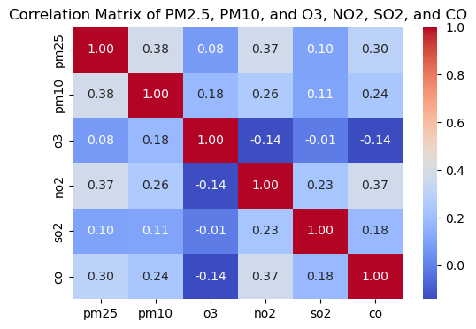

```python
plt.figure(figsize=(6, 4))
sns.heatmap(df_gwanak_joined[['pm25', 'pm10', 'o3', 'no2', 'so2', 'co']].corr(), annot=True, cmap='coolwarm', fmt=".2f")
plt.title('Correlation Matrix of PM2.5, PM10, and O3, NO2, SO2, and CO')
plt.show()
```

Let's now plot the relationship between temperature and PM2.5, followed by precipitation and PM2.5. We'll generate a plot for each region, with PM2.5 values indicated by the left y-axis and temperature values indicated by the right y-axis, focusing on 2021 alone.

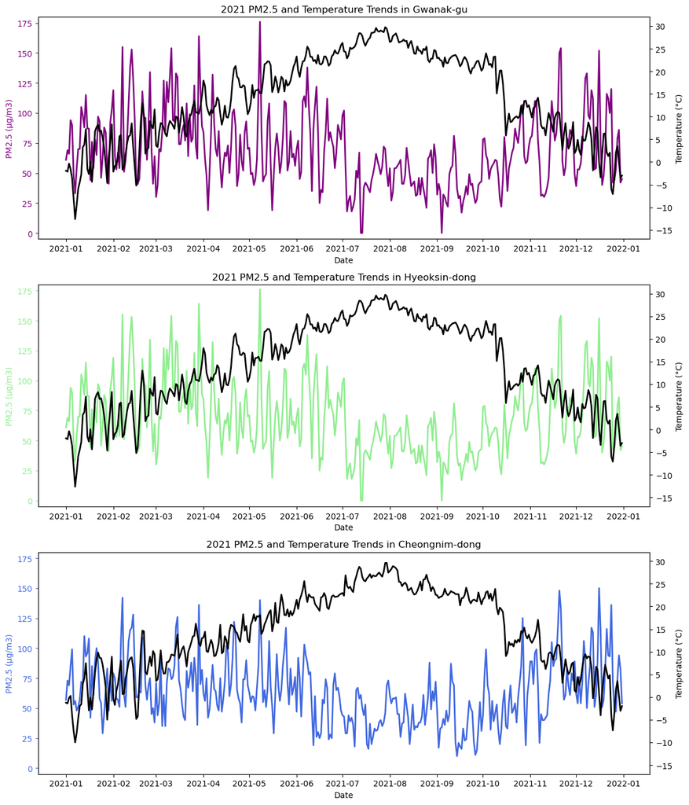

```python
df_gwanak_joined_2021 = df_gwanak_joined.query("date >= '2021-01-01' and date <= '2021-12-31'")
df_hyeoksin_joined_2021 = df_hyeoksin_joined.query("date >= '2021-01-01' and date <= '2021-12-31'")
df_cheongnim_joined_2021 = df_cheongnim_joined.query("date >= '2021-01-01' and date <= '2021-12-31'")

plt.figure(figsize=(12, 14))

pm25_bounds = (-5, 180)
pm25_ticks = range(0, 176, 25)
temp_bounds = (-17, 32)
temp_ticks = range(-15, 31, 5)

ax1 = plt.subplot(3, 1, 1)
ax1.plot(df_gwanak_joined_2021['date'], df_gwanak_joined_2021['pm25'], color='purple', label='PM2.5 (µg/m3)', linewidth=2)
ax1.set_ylim(pm25_bounds)
ax1.set_yticks(pm25_ticks)
ax1.set_ylabel('PM2.5 (µg/m3)', color='purple')
ax1.tick_params(axis='y', colors='purple')

ax1_twin = ax1.twinx()
ax1_twin.plot(df_gwanak_joined_2021['date'], df_gwanak_joined_2021['temperature_2m_mean'], color='black', label='Temperature (°C)', linewidth=2)
ax1_twin.set_ylim(temp_bounds)
ax1_twin.set_yticks(temp_ticks)
ax1_twin.set_ylabel('Temperature (°C)', color='black')
ax1_twin.tick_params(axis='y', colors='black')

ax1.set_title('2021 PM2.5 and Temperature Trends in Gwanak-gu')
ax1.set_xlabel('Date')

ax2 = plt.subplot(3, 1, 2)
ax2.plot(df_hyeoksin_joined_2021['date'], df_hyeoksin_joined_2021['pm25'], color='lightgreen', label='PM2.5 (µg/m3)', linewidth=2)
ax2.set_ylim(pm25_bounds)
ax2.set_yticks(pm25_ticks)
ax2.set_ylabel('PM2.5 (µg/m3)', color='lightgreen')
ax2.tick_params(axis='y', colors='lightgreen')

ax2_twin = ax2.twinx()
ax2_twin.plot(df_hyeoksin_joined_2021['date'], df_hyeoksin_joined_2021['temperature_2m_mean'], color='black', label='Temperature (°C)', linewidth=2)
ax2_twin.set_ylim(temp_bounds)
ax2_twin.set_yticks(temp_ticks)
ax2_twin.set_ylabel('Temperature (°C)', color='black')
ax2_twin.tick_params(axis='y', colors='black')

ax2.set_title('2021 PM2.5 and Temperature Trends in Hyeoksin-dong')
ax2.set_xlabel('Date')

ax3 = plt.subplot(3, 1, 3)
ax3.plot(df_cheongnim_joined_2021['date'], df_cheongnim_joined_2021['pm25'], color='royalblue', label='PM2.5 (µg/m3)', linewidth=2)
ax3.set_ylim(pm25_bounds)
ax3.set_yticks(pm25_ticks)
ax3.set_ylabel('PM2.5 (µg/m3)', color='royalblue')
ax3.tick_params(axis='y', colors='royalblue')

ax3_twin = ax3.twinx()
ax3_twin.plot(df_cheongnim_joined_2021['date'], df_cheongnim_joined_2021['temperature_2m_mean'], color='black', label='Temperature (°C)', linewidth=2)
ax3_twin.set_ylim(temp_bounds)
ax3_twin.set_yticks(temp_ticks)
ax3_twin.set_ylabel('Temperature (°C)', color='black')
ax3_twin.tick_params(axis='y', colors='black')

ax3.set_title('2021 PM2.5 and Temperature Trends in Cheongnim-dong')
ax3.set_xlabel('Date')

for ax in [ax1, ax2, ax3]:
    ax.xaxis.set_major_locator(mdates.MonthLocator())
    ax.xaxis.set_major_formatter(mdates.DateFormatter('%Y-%m'))
    ax.tick_params(axis='x')

plt.subplots_adjust(hspace=0.3)
plt.tight_layout()
plt.show()
```

There is an inverse trend between temperature and PM2.5 levels, with temperature peaking in the summer (July-August) and PM2.5 peaking in the winter (December-February). This suggests that warmer temperatures have a positive effect on air quality. Interestingly, though, there appears to be more variation in PM2.5 within months, characterized by sharp spikes and drops, than variation between consecutive months. This variation is more pronounced in Gwanak-gu and Hyeoksin-dong, both situated in larger cities on the on the continent’s western side, where air quality tends to be slightly worse. In contrast, Cheongnim-dong, located in the far east, receives less fine dust pollution from China, resulting in more stable air quality with lighter fluctuations.

The significant variation within months suggests that short-term factors, such as precipitation, may have a stronger influence on PM2.5 levels than long-term factors, like temperature. To evaluate this, we can examine PM2.5 vs. precipitation charts:

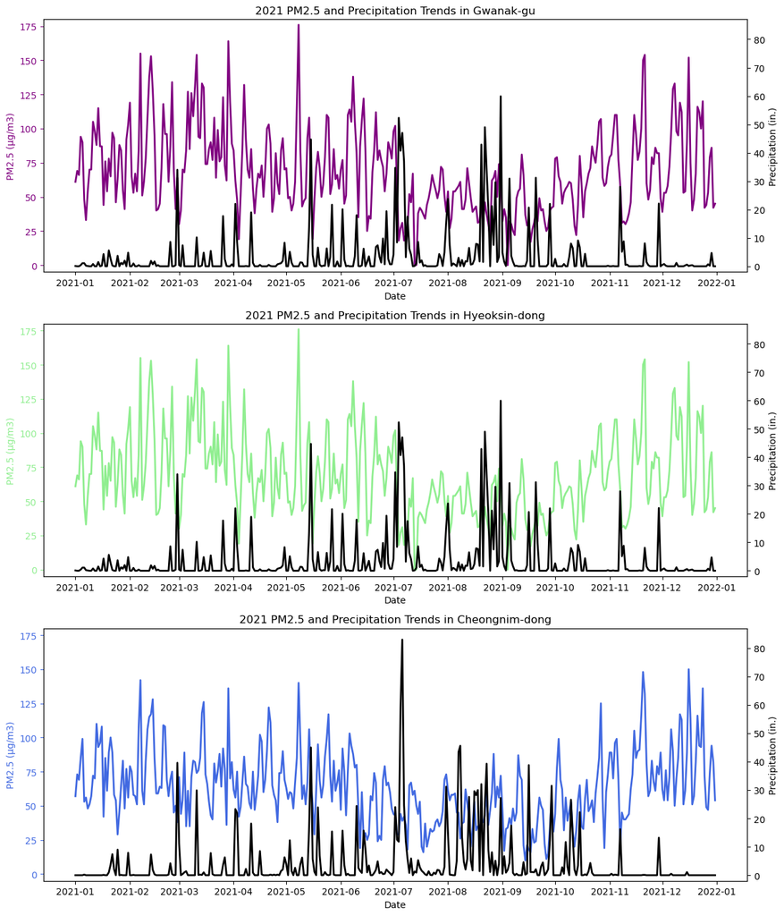

```python
plt.figure(figsize=(12, 14))

pm25_bounds = (-5, 180)
pm25_ticks = range(0, 176, 25)
precip_bounds = (-2, 87)
precip_ticks = range(0, 85, 10)

ax1 = plt.subplot(3, 1, 1)
ax1.plot(df_gwanak_joined_2021['date'], df_gwanak_joined_2021['pm25'], color='purple', label='PM2.5 (µg/m3)', linewidth=2)
ax1.set_ylim(pm25_bounds)
ax1.set_yticks(pm25_ticks)
ax1.set_ylabel('PM2.5 (µg/m3)', color='purple')
ax1.tick_params(axis='y', colors='purple')

ax1_twin = ax1.twinx()
ax1_twin.plot(df_gwanak_joined_2021['date'], df_gwanak_joined_2021['precipitation_sum'], color='black', label='Precipitation (in.)', linewidth=2)
ax1_twin.set_ylim(precip_bounds)
ax1_twin.set_yticks(precip_ticks)
ax1_twin.set_ylabel('Precipitation (in.)', color='black')
ax1_twin.tick_params(axis='y', colors='black')

ax1.set_title('2021 PM2.5 and Precipitation Trends in Gwanak-gu')
ax1.set_xlabel('Date')

ax2 = plt.subplot(3, 1, 2)
ax2.plot(df_hyeoksin_joined_2021['date'], df_hyeoksin_joined_2021['pm25'], color='lightgreen', label='PM2.5 (µg/m3)', linewidth=2)
ax2.set_ylim(pm25_bounds)
ax2.set_yticks(pm25_ticks)
ax2.set_ylabel('PM2.5 (µg/m3)', color='lightgreen')
ax2.tick_params(axis='y', colors='lightgreen')

ax2_twin = ax2.twinx()
ax2_twin.plot(df_hyeoksin_joined_2021['date'], df_hyeoksin_joined_2021['precipitation_sum'], color='black', label='Precipitation (in.)', linewidth=2)
ax2_twin.set_ylim(precip_bounds)
ax2_twin.set_yticks(precip_ticks)
ax2_twin.set_ylabel('Precipitation (in.)', color='black')
ax2_twin.tick_params(axis='y', colors='black')

ax2.set_title('2021 PM2.5 and Precipitation Trends in Hyeoksin-dong')
ax2.set_xlabel('Date')

ax3 = plt.subplot(3, 1, 3)
ax3.plot(df_cheongnim_joined_2021['date'], df_cheongnim_joined_2021['pm25'], color='royalblue', label='PM2.5 (µg/m3)', linewidth=2)
ax3.set_ylim(pm25_bounds)
ax3.set_yticks(pm25_ticks)
ax3.set_ylabel('PM2.5 (µg/m3)', color='royalblue')
ax3.tick_params(axis='y', colors='royalblue')

ax3_twin = ax3.twinx()
ax3_twin.plot(df_cheongnim_joined_2021['date'], df_cheongnim_joined_2021['precipitation_sum'], color='black', label='Precipitation (in.)', linewidth=2)
ax3_twin.set_ylim(precip_bounds)
ax3_twin.set_yticks(precip_ticks)
ax3_twin.set_ylabel('Precipitation (in.)', color='black')
ax3_twin.tick_params(axis='y', colors='black')

ax3.set_title('2021 PM2.5 and Precipitation Trends in Cheongnim-dong')
ax3.set_xlabel('Date')

for ax in [ax1, ax2, ax3]:
    ax.xaxis.set_major_locator(mdates.MonthLocator())
    ax.xaxis.set_major_formatter(mdates.DateFormatter('%Y-%m'))
    ax.tick_params(axis='x')

plt.subplots_adjust(hspace=0.3)
plt.tight_layout()
plt.show()
```

Unlike temperature, precipitation does not follow seasonal trends as clearly, making it more difficult to assess its relationship with PM2.5 solely through visualizations. That said, the months with the most frequent and extreme precipitation activity (July through September) do correlate with lower levels of PM2.5. In addition, there are several days around March 1st, April 1st, and mid-May where a sharp decline in PM2.5 immediately follows a day with heavy precipitation. This follows what we understand about precipitation capturing particulate matter and falling to the ground.

Before modeling, let's run a calculate a few statistical tests to further assess the relationship between these variables. We can start with simple correlation values:

```python
temp_corr = df_complete[['temperature_2m_mean', 'pm25']].corr().loc['temperature_2m_mean', 'pm25']
precip_corr = df_complete[['precipitation_sum', 'pm25']].corr().loc['precipitation_sum', 'pm25']

print(f"Temperature & PM2.5 Correlation: {temp_corr:.3f}")
print(f"Precipitation & PM2.5 Correlation: {precip_corr:.3f}")
```

```
Temperature & PM2.5 Correlation: -0.252
Precipitation & PM2.5 Correlation: -0.112
```

```python
for region_name, region_df in zip(
    ["Gwanak-Gu", "Hyeoksin-Dong", "Cheongnim-Dong"],
    [df_complete_gwanak, df_complete_hyeoksin, df_complete_cheongnim]):

    temp_corr = region_df[['temperature_2m_mean', 'pm25']].corr().loc['temperature_2m_mean', 'pm25']
    precip_corr = region_df[['precipitation_sum', 'pm25']].corr().loc['precipitation_sum', 'pm25']
    print(f"{region_name} - Temperature & PM2.5 Correlation: {temp_corr:.3f}")
    print(f"{region_name} - Precipitation & PM2.5 Correlation: {precip_corr:.3f}\n")
```

```
Gwanak-Gu - Temperature & PM2.5 Correlation: -0.207
Gwanak-Gu - Precipitation & PM2.5 Correlation: -0.082

Hyeoksin-Dong - Temperature & PM2.5 Correlation: -0.315
Hyeoksin-Dong - Precipitation & PM2.5 Correlation: -0.140

Cheongnim-Dong - Temperature & PM2.5 Correlation: -0.382
Cheongnim-Dong - Precipitation & PM2.5 Correlation: -0.156
```

Our correlation coefficients do not display any strong trends. However, they suggest that temperature has a weak inverse effect on PM2.5, and that precipitation has a very weak inverse effect on PM2.5. We expected PM2.5 values to decrease as temperature and precipitation increase, but not necessarily for temperature to have a stronger effect on PM2.5 than precipitation does.

The variations in correlation coefficients between regions suggest that areas farther from China exhibit a stronger relationship between temperature, precipitation, and PM2.5 levels. With Gwanak-gu being the closest to China and Cheongnim-dong the farthest, there is a logical reason why our coefficients are stronger in regions farther from China. As previously suggested, temperature and precipitation are greater factors in determining air quality in these regions due to less pollution from China. Specifically, Cheongnim-dong, which receives the least fine dust from China, shows the strongest negative correlations. In contrast, Gwanak-gu, more exposed to external pollution sources, displays weaker correlations, suggesting that pollutants from overseas have a greater impact on air quality.

Our next step is to include a temporal aspect. We can incorporate a "lag" in our correlation statistics that assesses PM2.5 values against temperature and precipitation values from 1, 2, and 3 days earlier. This is necessary as the effect of temperature and precipitation on PM2.5 may not always take place within a day; for example, a certain temperature pattern on a Tuesday could have larger implications for Wednesday's air quality rather than the air quality of that same day.

```python
for lag in range(0, 4):
    temp_corr = df_complete['temperature_2m_mean'].corr(df_complete['pm25'].shift(lag))
    print(f"{lag}-day lag correlation (Temp & PM2.5): {temp_corr:.3f}")

    precip_corr = df_complete['precipitation_sum'].corr(df_complete['pm25'].shift(lag))
    print(f"{lag}-day lag correlation (Precip & PM2.5): {precip_corr: .3f}")
```

```
0-day lag correlation (Temp & PM2.5): -0.252
0-day lag correlation (Precip & PM2.5): -0.112
1-day lag correlation (Temp & PM2.5): -0.282
1-day lag correlation (Precip & PM2.5): -0.078
2-day lag correlation (Temp & PM2.5): -0.296
2-day lag correlation (Precip & PM2.5): -0.089
3-day lag correlation (Temp & PM2.5): -0.290
3-day lag correlation (Precip & PM2.5): -0.082
```

```python
for lag in range(0, 4):
    temp_corr = df_complete_gwanak['temperature_2m_mean'].corr(df_complete_gwanak['pm25'].shift(lag))
    print(f"Gwanak-gu {lag}-day lag correlation (Temp & PM2.5): {temp_corr:.3f}")

    precip_corr = df_complete_gwanak['precipitation_sum'].corr(df_complete_gwanak['pm25'].shift(lag))
    print(f"Gwanak-gu {lag}-day lag correlation (Precip & PM2.5): {precip_corr: .3f}")

print(' ')

for lag in range(0, 4):
    temp_corr = df_complete_hyeoksin['temperature_2m_mean'].corr(df_complete_hyeoksin['pm25'].shift(lag))
    print(f"Hyeoksin-dong {lag}-day lag correlation (Temp & PM2.5): {temp_corr:.3f}")

    precip_corr = df_complete_hyeoksin['precipitation_sum'].corr(df_complete_hyeoksin['pm25'].shift(lag))
    print(f"Hyeoksin-dong {lag}-day lag correlation (Precip & PM2.5): {precip_corr: .3f}")

print(' ')

for lag in range(0, 4):
    temp_corr = df_complete_cheongnim['temperature_2m_mean'].corr(df_complete_cheongnim['pm25'].shift(lag))
    print(f"Cheongnim-dong {lag}-day lag correlation (Temp & PM2.5): {temp_corr:.3f}")

    precip_corr = df_complete_cheongnim['precipitation_sum'].corr(df_complete_cheongnim['pm25'].shift(lag))
    print(f"Cheongnim-dong {lag}-day lag correlation (Precip & PM2.5): {precip_corr: .3f}")
```

```
Gwanak-gu 0-day lag correlation (Temp & PM2.5): -0.207
Gwanak-gu 0-day lag correlation (Precip & PM2.5): -0.082
Gwanak-gu 1-day lag correlation (Temp & PM2.5): -0.233
Gwanak-gu 1-day lag correlation (Precip & PM2.5): -0.051
Gwanak-gu 2-day lag correlation (Temp & PM2.5): -0.248
Gwanak-gu 2-day lag correlation (Precip & PM2.5): -0.076
Gwanak-gu 3-day lag correlation (Temp & PM2.5): -0.247
Gwanak-gu 3-day lag correlation (Precip & PM2.5): -0.069

Hyeoksin-dong 0-day lag correlation (Temp & PM2.5): -0.315
Hyeoksin-dong 0-day lag correlation (Precip & PM2.5): -0.140
Hyeoksin-dong 1-day lag correlation (Temp & PM2.5): -0.351
Hyeoksin-dong 1-day lag correlation (Precip & PM2.5): -0.100
Hyeoksin-dong 2-day lag correlation (Temp & PM2.5): -0.364
Hyeoksin-dong 2-day lag correlation (Precip & PM2.5): -0.085
Hyeoksin-dong 3-day lag correlation (Temp & PM2.5): -0.343
Hyeoksin-dong 3-day lag correlation (Precip & PM2.5): -0.051

Cheongnim-dong 0-day lag correlation (Temp & PM2.5): -0.382
Cheongnim-dong 0-day lag correlation (Precip & PM2.5): -0.156
Cheongnim-dong 1-day lag correlation (Temp & PM2.5): -0.429
Cheongnim-dong 1-day lag correlation (Precip & PM2.5): -0.121
Cheongnim-dong 2-day lag correlation (Temp & PM2.5): -0.439
Cheongnim-dong 2-day lag correlation (Precip & PM2.5): -0.117
Cheongnim-dong 3-day lag correlation (Temp & PM2.5): -0.424
Cheongnim-dong 3-day lag correlation (Precip & PM2.5): -0.127
```

These trends hold across the three regions, with the temperature-PM2.5 correlation peaking at a 2-day lag. At the same time, the correlation between precipitation and PM2.5 either drops or remains roughly constant with increasing lag. This suggests that the effects of lag on climate and PM2.5 and are consistent across regions despite the relationship between climate and PM2.5 varying across regions.

Thus far, we've observed that the relationships between our three variables are not overwhelmingly strong when measured daily. Let's build a model to identify more subtle trends in our data.

## Modeling

During the modeling phase, we'll use the Gwanak dataset, which spans from 2015 to 2021. However, we'll limit data to 2015-2019 to avoid the impacts of the COVID-19 pandemic on our models. While using the Cheongnim dataset might result in stronger models due to its slightly stronger relationships between climate and PM2.5, its data is limited to 2019-2021. Moreover, modeling the air quality in Gwanak, located in Seoul, home to nearly 10 million people, may hold more real-world relevance.

We'll work with XGBoost, a reliable and flexible modeling method that works via gradient boosting. It will take in *temperature_2m_mean* and *precipitation_sum* as features to model *pm25*. RMSE will be used as a model evaluation metric, and feature importance charts will indicate which features are of most value to the model. We'll also implement k-fold cross validation in order to use each year between 2015 and 2019 as the test set. This will ensure a more robust model, as 2019, or any year, could display unusual climate and PM2.5 patterns compared to surrounding years.

```
RMSE List (4-fold CV + test): [27.633705172509973, 26.99301630924278, 33.82547057858656, 35.0744200505293, 33.81501878605958]
Avg. RMSE: 31.468326179385638
R² List (4-fold CV + test): [-0.15623367822726886, -0.06536557959588474, -0.1933004540355756, -0.02689792130862978, 0.10186929695683067]
Avg. R²: -0.06798566724210567
```

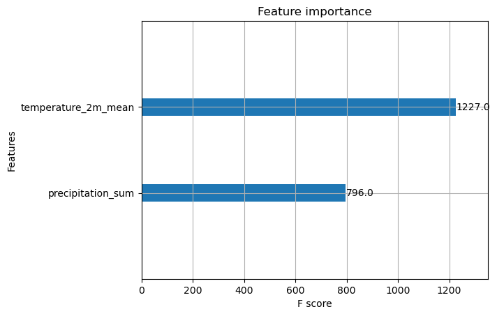

```python
df_mod = df_complete_gwanak.query("date.dt.year <= 2019")

def cv_by_year(X, y, n_splits=4):
    time_split = TimeSeriesSplit(n_splits=4)
    rmse_list = []
    r2_list = []

    for train_i, test_i in time_split.split(X):
        X_train_cv, X_test_cv = X.iloc[train_i], X.iloc[test_i]
        y_train_cv, y_test_cv = y.iloc[train_i], y.iloc[test_i]
        model = xgb.XGBRegressor(n_estimators=300, learning_rate=0.03, max_depth=3, random_state=0)
        model.fit(X_train_cv, y_train_cv)
        y_pred_cv = model.predict(X_test_cv)
        rmse_list.append(root_mean_squared_error(y_test_cv, y_pred_cv))
        r2_list.append(r2_score(y_test_cv, y_pred_cv))

    return rmse_list, r2_list

train = df_mod.query('date.dt.year < 2019')
test = df_mod.query('date.dt.year == 2019')
X_train, y_train = train[['temperature_2m_mean', 'precipitation_sum']], train['pm25']
X_test, y_test = test[['temperature_2m_mean', 'precipitation_sum']], test['pm25']

rmse_list, r2_list = cv_by_year(X_train,y_train)

model = xgb.XGBRegressor(n_estimators=300, learning_rate=0.03, max_depth=3, random_state=0)
model.fit(X_train, y_train)
y_preds = model.predict(X_test)

test_rmse = root_mean_squared_error(y_test, y_preds)
test_r2 = r2_score(y_test, y_preds)

rmse_list = rmse_list + [test_rmse]
r2_list = r2_list + [test_r2]
avg_rmse = sum(rmse_list) / len(rmse_list)
avg_r2 = sum(r2_list) / len(r2_list)

print("RMSE List (4-fold CV + test):", rmse_list)
print("Avg. RMSE:", avg_rmse)
print("R² List (4-fold CV + test):", r2_list)
print("Avg. R²:", avg_r2)

xgb.plot_importance(model)
```

Our base XGBoost model has an average RMSE of 31.47, meaning it predicts, on average, PM2.5 values 31.47 units away from the actual values in the test year. Moreover, the slightly negative R² tells us that our model is performing a bit worse than a simple model that predicts the mean PM2.5. In short, this model is very weak. However, we can still extrapolate from the feature importance chart that temperature was utilized more by the model to make its predictions. This aligns with the higher correlation between temperature and PM2.5 (compared to precipitation and PM2.5) we observed earlier.

Let's now implement a lag and observe how our model improves. A lag allows us to incorporate past temperaure and precipitation values when predicting today's PM2.5 levels. This is worthwhile, as temperature from July 10th, for example, may not only affect July 10th, but also July 11th, July 12th, etc. We'll test all combinations of lag values between 1 and 5. This means we’ll check how well the model performs when using just a 1-day lag, a 3-day and 5-day lag together, a 1-day, 2-day, and 4-day lag together, and so on.

(The values 1-5 were chosen based on intuition; higher values could be tested but this runs the risk of overfitting. And realistically, temperature and precipitation are unlikely to affect PM2.5 values 6 days out and onwards.)

```
Lags: (1, 2, 3, 5) | CV Avg. RMSE: 27.327 | CV Avg. R²: 0.121
Lags: (0, 1, 2, 3, 4, 5) | CV Avg. RMSE: 27.342 | CV Avg. R²: 0.118
Lags: (1, 2, 3, 4, 5) | CV Avg. RMSE: 27.364 | CV Avg. R²: 0.116
Lags: (1, 3, 5) | CV Avg. RMSE: 27.399 | CV Avg. R²: 0.118
Lags: (0, 1, 2, 3, 5) | CV Avg. RMSE: 27.435 | CV Avg. R²: 0.114
Lags: (0, 1, 2, 4, 5) | CV Avg. RMSE: 27.467 | CV Avg. R²: 0.11
Lags: (1, 2, 3, 4) | CV Avg. RMSE: 27.485 | CV Avg. R²: 0.109
Lags: (0, 1, 3, 4, 5) | CV Avg. RMSE: 27.523 | CV Avg. R²: 0.107
Lags: (1, 3, 4, 5) | CV Avg. RMSE: 27.534 | CV Avg. R²: 0.107
Lags: (0, 1, 3, 5) | CV Avg. RMSE: 27.604 | CV Avg. R²: 0.104
Lags: (1, 2, 3) | CV Avg. RMSE: 27.612 | CV Avg. R²: 0.103
Lags: (1, 2, 4, 5) | CV Avg. RMSE: 27.648 | CV Avg. R²: 0.097
Lags: (0, 1, 2, 5) | CV Avg. RMSE: 27.667 | CV Avg. R²: 0.097
Lags: (0, 1, 3, 4) | CV Avg. RMSE: 27.669 | CV Avg. R²: 0.098
Lags: (1, 3, 4) | CV Avg. RMSE: 27.672 | CV Avg. R²: 0.097
Lags: (1, 2, 4) | CV Avg. RMSE: 27.705 | CV Avg. R²: 0.094
Lags: (0, 1, 2, 3, 4) | CV Avg. RMSE: 27.705 | CV Avg. R²: 0.095
Lags: (1, 2, 5) | CV Avg. RMSE: 27.707 | CV Avg. R²: 0.095
Lags: (0, 1, 2, 4) | CV Avg. RMSE: 27.737 | CV Avg. R²: 0.094
Lags: (0, 1, 4, 5) | CV Avg. RMSE: 27.768 | CV Avg. R²: 0.091
Lags: (1, 4) | CV Avg. RMSE: 27.792 | CV Avg. R²: 0.089
Lags: (0, 1, 4) | CV Avg. RMSE: 27.794 | CV Avg. R²: 0.089
Lags: (1, 4, 5) | CV Avg. RMSE: 27.801 | CV Avg. R²: 0.087
Lags: (1, 3) | CV Avg. RMSE: 27.861 | CV Avg. R²: 0.09
Lags: (1, 5) | CV Avg. RMSE: 27.922 | CV Avg. R²: 0.083
Lags: (0, 1, 2, 3) | CV Avg. RMSE: 27.927 | CV Avg. R²: 0.082
Lags: (0, 1, 3) | CV Avg. RMSE: 28.051 | CV Avg. R²: 0.076
Lags: (0, 1, 5) | CV Avg. RMSE: 28.065 | CV Avg. R²: 0.073
Lags: (0, 2, 3, 4) | CV Avg. RMSE: 28.144 | CV Avg. R²: 0.069
Lags: (0, 2, 3, 4, 5) | CV Avg. RMSE: 28.196 | CV Avg. R²: 0.063
Lags: (0, 2, 3, 5) | CV Avg. RMSE: 28.203 | CV Avg. R²: 0.064
Lags: (0, 2, 3) | CV Avg. RMSE: 28.214 | CV Avg. R²: 0.066
Lags: (0, 2, 4) | CV Avg. RMSE: 28.217 | CV Avg. R²: 0.064
Lags: (0, 2, 4, 5) | CV Avg. RMSE: 28.301 | CV Avg. R²: 0.055
Lags: (2, 3) | CV Avg. RMSE: 28.636 | CV Avg. R²: 0.036
Lags: (1, 2) | CV Avg. RMSE: 28.64 | CV Avg. R²: 0.036
Lags: (2, 3, 4) | CV Avg. RMSE: 28.703 | CV Avg. R²: 0.028
Lags: (0, 3, 4, 5) | CV Avg. RMSE: 28.707 | CV Avg. R²: 0.028
Lags: (0, 2, 5) | CV Avg. RMSE: 28.722 | CV Avg. R²: 0.028
Lags: (0, 3, 4) | CV Avg. RMSE: 28.723 | CV Avg. R²: 0.029
```

[output cut: 8 more lines]

```
Lags: (2, 5) | CV Avg. RMSE: 29.239 | CV Avg. R²: -0.01
Lags: (2,) | CV Avg. RMSE: 29.242 | CV Avg. R²: -0.003
Lags: (0, 3) | CV Avg. RMSE: 29.266 | CV Avg. R²: -0.007
Lags: (0, 5) | CV Avg. RMSE: 29.342 | CV Avg. R²: -0.017
Lags: (0, 2) | CV Avg. RMSE: 29.398 | CV Avg. R²: -0.014
Lags: (1,) | CV Avg. RMSE: 29.613 | CV Avg. R²: -0.023
Lags: (0, 1) | CV Avg. RMSE: 29.734 | CV Avg. R²: -0.031
Lags: (3,) | CV Avg. RMSE: 30.04 | CV Avg. R²: -0.061
Lags: (3, 4) | CV Avg. RMSE: 30.201 | CV Avg. R²: -0.078
Lags: (3, 5) | CV Avg. RMSE: 30.411 | CV Avg. R²: -0.089
Lags: (3, 4, 5) | CV Avg. RMSE: 30.457 | CV Avg. R²: -0.096
Lags: (4,) | CV Avg. RMSE: 30.547 | CV Avg. R²: -0.1
Lags: (0,) | CV Avg. RMSE: 30.882 | CV Avg. R²: -0.11
Lags: (5,) | CV Avg. RMSE: 30.993 | CV Avg. R²: -0.135
Lags: (4, 5) | CV Avg. RMSE: 31.035 | CV Avg. R²: -0.141
```

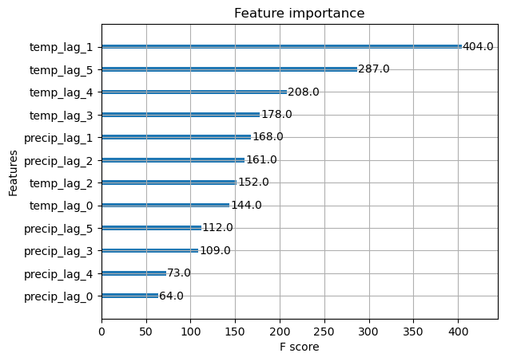

```python
lags = [0, 1, 2, 3, 4, 5]

lag_combos = []
for i in range(1, len(lags) + 1):
    combos = itertools.combinations(lags, i)
    for x in combos:
        lag_combos.append(x)


res = []
for combo in lag_combos:
    df_tmp = df_mod.copy()
    for lag in combo:
        df_tmp[f'temp_lag_{lag}'] = df_tmp['temperature_2m_mean'].shift(lag)
        df_tmp[f'precip_lag_{lag}'] = df_tmp['precipitation_sum'].shift(lag)
    df_tmp = df_tmp.dropna()

    train = df_tmp.query('date.dt.year < 2019')
    feats = [f'temp_lag_{i}' for i in combo] + [f'precip_lag_{i}' for i in combo]
    X_train = train[feats]
    y_train = train['pm25']
    rmse_list, r2_list = cv_by_year(X_train, y_train)
    res.append({
         'lags': combo,
         'rmse_list': round(sum(rmse_list)/len(rmse_list), 3),
         'r2_list': round(sum(r2_list)/len(r2_list), 3)
    })

res = sorted(res, key=lambda x: x['rmse_list'])
for i in res:
    print(f"Lags: {i['lags']} | CV Avg. RMSE: {i['rmse_list']} | CV Avg. R²: {i['r2_list']}")

df_all = df_mod.copy()
for i in lags:
    df_all[f'temp_lag_{i}'] = df_all['temperature_2m_mean'].shift(i)
    df_all[f'precip_lag_{i}'] = df_all['precipitation_sum'].shift(i)
df_all = df_all.dropna()

train_all = df_all.query('date.dt.year < 2019')
feats_all = [f'temp_lag_{i}' for i in lags] + [f'precip_lag_{i}' for i in lags]
X_all = train_all[feats_all]
y_all = train_all['pm25']

full_model = xgb.XGBRegressor(n_estimators=300, learning_rate=0.03, max_depth=3,random_state=0)
full_model.fit(X_all, y_all)
xgb.plot_importance(full_model)
```

The optimal lag combination, with the lowest RMSE and highest R², is (1, 2, 3, 5), however the full lag combo (0, 1, 2, 3, 4, 5) has virtually the same performance. This indicates that incorporating 1-day, 2-day, 3-day, 4-day, and 5-day lags improved our model. While keeping the same machine learning algorithm and hyperparameters, incorporating a lag increased our R² from -0.07 to 0.121. An R² of 0.121 means that approximately 12.1% of the variability in PM2.5 values can be explained by same-day and lagged temperature and precipitation values together. Our model may be better than simply predicted the average PM2.5 value for every day, but our low R² indicates that a lot of other factors shape each day's PM2.5 levels.

Additionally, our feature importance chart once again displays temperature being a more important feature than precipitation. It also rank 1-day lagged temperature as the feature with the most predictive power. This suggests that the temperature of the previous day is the most important temperature metric in predicting PM2.5. However, same-day temperature was least important of all temperature features, suggesting that same-day temperature is not as important after all. This finding may change as we develop our model and add more features.

Let's also investigate how lagged PM2.5 values themselves can be used. We'll now use previous values of temperature, precipitation, and PM2.5 itself to model PM2.5. In essence, we are trying to determine what additional value we add to our model when incorporating PM2.5 values as a feature.

```
Temp/Precip Lags: [1, 2, 3] | PM2.5 Lags: [1, 2, 3] | CV Avg. RMSE: 21.929 | CV Avg. R²: 0.425
Temp/Precip Lags: [0, 1, 2, 3] | PM2.5 Lags: [1, 2, 3] | CV Avg. RMSE: 22.041 | CV Avg. R²: 0.42
Temp/Precip Lags: [0, 1, 2, 3, 5] | PM2.5 Lags: [1, 2, 3, 5] | CV Avg. RMSE: 22.023 | CV Avg. R²: 0.42
Temp/Precip Lags: [1, 2] | PM2.5 Lags: [1, 2] | CV Avg. RMSE: 22.002 | CV Avg. R²: 0.419
Temp/Precip Lags: [0, 1, 2] | PM2.5 Lags: [1, 2] | CV Avg. RMSE: 22.03 | CV Avg. R²: 0.417
Temp/Precip Lags: [1, 3] | PM2.5 Lags: [1, 3] | CV Avg. RMSE: 22.079 | CV Avg. R²: 0.416
Temp/Precip Lags: [1, 2, 3, 5] | PM2.5 Lags: [1, 2, 3, 5] | CV Avg. RMSE: 22.07 | CV Avg. R²: 0.416
Temp/Precip Lags: [0, 1, 2, 5] | PM2.5 Lags: [1, 2, 5] | CV Avg. RMSE: 22.099 | CV Avg. R²: 0.415
Temp/Precip Lags: [1, 2, 5] | PM2.5 Lags: [1, 2, 5] | CV Avg. RMSE: 22.087 | CV Avg. R²: 0.414
Temp/Precip Lags: [0, 1, 3, 5] | PM2.5 Lags: [1, 3, 5] | CV Avg. RMSE: 22.179 | CV Avg. R²: 0.41
Temp/Precip Lags: [0, 1, 3] | PM2.5 Lags: [1, 3] | CV Avg. RMSE: 22.245 | CV Avg. R²: 0.407
Temp/Precip Lags: [1, 3, 5] | PM2.5 Lags: [1, 3, 5] | CV Avg. RMSE: 22.225 | CV Avg. R²: 0.407
Temp/Precip Lags: [1, 2, 3, 4] | PM2.5 Lags: [1, 2, 3, 4] | CV Avg. RMSE: 22.324 | CV Avg. R²: 0.403
Temp/Precip Lags: [1, 2, 3, 4, 5] | PM2.5 Lags: [1, 2, 3, 4, 5] | CV Avg. RMSE: 22.303 | CV Avg. R²: 0.402
Temp/Precip Lags: [0, 1, 2, 3, 4] | PM2.5 Lags: [1, 2, 3, 4] | CV Avg. RMSE: 22.358 | CV Avg. R²: 0.4
Temp/Precip Lags: [0, 1, 2, 3, 4, 5] | PM2.5 Lags: [1, 2, 3, 4, 5] | CV Avg. RMSE: 22.357 | CV Avg. R²: 0.399
Temp/Precip Lags: [1, 5] | PM2.5 Lags: [1, 5] | CV Avg. RMSE: 22.471 | CV Avg. R²: 0.394
Temp/Precip Lags: [0, 1, 2, 4] | PM2.5 Lags: [1, 2, 4] | CV Avg. RMSE: 22.487 | CV Avg. R²: 0.394
Temp/Precip Lags: [0, 1, 3, 4, 5] | PM2.5 Lags: [1, 3, 4, 5] | CV Avg. RMSE: 22.481 | CV Avg. R²: 0.394
Temp/Precip Lags: [1, 2, 4] | PM2.5 Lags: [1, 2, 4] | CV Avg. RMSE: 22.469 | CV Avg. R²: 0.393
Temp/Precip Lags: [1, 3, 4, 5] | PM2.5 Lags: [1, 3, 4, 5] | CV Avg. RMSE: 22.514 | CV Avg. R²: 0.392
Temp/Precip Lags: [0, 1, 2, 4, 5] | PM2.5 Lags: [1, 2, 4, 5] | CV Avg. RMSE: 22.452 | CV Avg. R²: 0.392
Temp/Precip Lags: [1, 3, 4] | PM2.5 Lags: [1, 3, 4] | CV Avg. RMSE: 22.516 | CV Avg. R²: 0.391
Temp/Precip Lags: [0, 1, 5] | PM2.5 Lags: [1, 5] | CV Avg. RMSE: 22.562 | CV Avg. R²: 0.39
Temp/Precip Lags: [1, 4, 5] | PM2.5 Lags: [1, 4, 5] | CV Avg. RMSE: 22.526 | CV Avg. R²: 0.389
Temp/Precip Lags: [0, 1, 3, 4] | PM2.5 Lags: [1, 3, 4] | CV Avg. RMSE: 22.574 | CV Avg. R²: 0.389
Temp/Precip Lags: [1, 2, 4, 5] | PM2.5 Lags: [1, 2, 4, 5] | CV Avg. RMSE: 22.524 | CV Avg. R²: 0.389
Temp/Precip Lags: [0, 1, 4, 5] | PM2.5 Lags: [1, 4, 5] | CV Avg. RMSE: 22.61 | CV Avg. R²: 0.386
Temp/Precip Lags: [1, 4] | PM2.5 Lags: [1, 4] | CV Avg. RMSE: 22.729 | CV Avg. R²: 0.381
Temp/Precip Lags: [0, 1, 4] | PM2.5 Lags: [1, 4] | CV Avg. RMSE: 22.764 | CV Avg. R²: 0.38
Temp/Precip Lags: [0, 1] | PM2.5 Lags: [1] | CV Avg. RMSE: 22.846 | CV Avg. R²: 0.377
Temp/Precip Lags: [1] | PM2.5 Lags: [1] | CV Avg. RMSE: 22.861 | CV Avg. R²: 0.375
Temp/Precip Lags: [0, 2, 3, 4] | PM2.5 Lags: [2, 3, 4] | CV Avg. RMSE: 26.445 | CV Avg. R²: 0.176
Temp/Precip Lags: [0, 2, 3] | PM2.5 Lags: [2, 3] | CV Avg. RMSE: 26.498 | CV Avg. R²: 0.171
Temp/Precip Lags: [0, 2, 4] | PM2.5 Lags: [2, 4] | CV Avg. RMSE: 26.575 | CV Avg. R²: 0.168
Temp/Precip Lags: [0, 2, 3, 4, 5] | PM2.5 Lags: [2, 3, 4, 5] | CV Avg. RMSE: 26.518 | CV Avg. R²: 0.168
Temp/Precip Lags: [0, 2, 4, 5] | PM2.5 Lags: [2, 4, 5] | CV Avg. RMSE: 26.57 | CV Avg. R²: 0.167
Temp/Precip Lags: [0, 2, 3, 5] | PM2.5 Lags: [2, 3, 5] | CV Avg. RMSE: 26.714 | CV Avg. R²: 0.153
Temp/Precip Lags: [0, 2, 5] | PM2.5 Lags: [2, 5] | CV Avg. RMSE: 26.819 | CV Avg. R²: 0.149
Temp/Precip Lags: [0, 2] | PM2.5 Lags: [2] | CV Avg. RMSE: 27.023 | CV Avg. R²: 0.135
```

[output cut: 8 more lines]

```
Temp/Precip Lags: [0, 3, 4] | PM2.5 Lags: [3, 4] | CV Avg. RMSE: 27.843 | CV Avg. R²: 0.09
Temp/Precip Lags: [0, 4] | PM2.5 Lags: [4] | CV Avg. RMSE: 28.087 | CV Avg. R²: 0.077
Temp/Precip Lags: [0, 3, 4, 5] | PM2.5 Lags: [3, 4, 5] | CV Avg. RMSE: 28.122 | CV Avg. R²: 0.066
Temp/Precip Lags: [0, 4, 5] | PM2.5 Lags: [4, 5] | CV Avg. RMSE: 28.282 | CV Avg. R²: 0.06
Temp/Precip Lags: [0, 3] | PM2.5 Lags: [3] | CV Avg. RMSE: 28.395 | CV Avg. R²: 0.051
Temp/Precip Lags: [0, 3, 5] | PM2.5 Lags: [3, 5] | CV Avg. RMSE: 28.525 | CV Avg. R²: 0.036
Temp/Precip Lags: [0, 5] | PM2.5 Lags: [5] | CV Avg. RMSE: 28.908 | CV Avg. R²: 0.014
Temp/Precip Lags: [3, 4] | PM2.5 Lags: [3, 4] | CV Avg. RMSE: 29.483 | CV Avg. R²: -0.023
Temp/Precip Lags: [3] | PM2.5 Lags: [3] | CV Avg. RMSE: 29.653 | CV Avg. R²: -0.039
Temp/Precip Lags: [4] | PM2.5 Lags: [4] | CV Avg. RMSE: 30.012 | CV Avg. R²: -0.055
Temp/Precip Lags: [3, 4, 5] | PM2.5 Lags: [3, 4, 5] | CV Avg. RMSE: 29.875 | CV Avg. R²: -0.055
Temp/Precip Lags: [3, 5] | PM2.5 Lags: [3, 5] | CV Avg. RMSE: 30.043 | CV Avg. R²: -0.068
Temp/Precip Lags: [4, 5] | PM2.5 Lags: [4, 5] | CV Avg. RMSE: 30.367 | CV Avg. R²: -0.087
Temp/Precip Lags: [0] | PM2.5 Lags: [] | CV Avg. RMSE: 30.882 | CV Avg. R²: -0.11
Temp/Precip Lags: [5] | PM2.5 Lags: [5] | CV Avg. RMSE: 30.849 | CV Avg. R²: -0.123
```

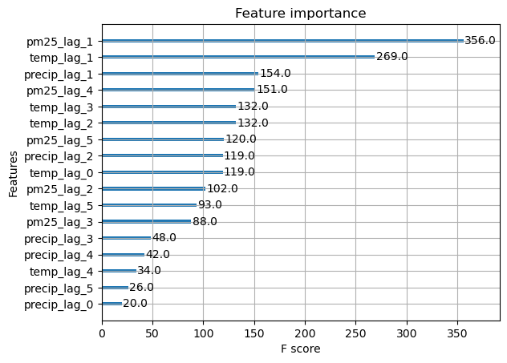

```python
lags_temp = [0, 1, 2, 3, 4, 5]
lags_pm = [1, 2, 3, 4, 5]

lag_combos = []
for i in range(1, len(lags_temp) + 1):
    combos = itertools.combinations(lags_temp, i)
    for x in combos:
        lag_combos.append(x)

res = []
for combo in lag_combos:
    df_tmp = df_mod.copy()
    for lag in combo:
        df_tmp[f'temp_lag_{lag}'] = df_tmp['temperature_2m_mean'].shift(lag)
        df_tmp[f'precip_lag_{lag}'] = df_tmp['precipitation_sum'].shift(lag)
    for lag in combo:
        if lag in lags_pm:
            df_tmp[f'pm25_lag_{lag}'] = df_tmp['pm25'].shift(lag)
    df_tmp = df_tmp.dropna()

    train = df_tmp.query('date.dt.year < 2019')
    feats = ([f'temp_lag_{i}' for i in combo] +
             [f'precip_lag_{i}' for i in combo] +
             [f'pm25_lag_{i}' for i in combo if i in lags_pm])
    X_train = train[feats]
    y_train = train['pm25']

    rmse_list, r2_list = cv_by_year(X_train, y_train)
    res.append({
        'combo': combo,
        'rmse_list': round(sum(rmse_list) / len(rmse_list), 3),
        'r2_list': round(sum(r2_list) / len(r2_list), 3)
    })

res = sorted(res,key=lambda x: x['r2_list'], reverse=True)
for i in res:
    temp = [lag for lag in i['combo'] if lag in lags_temp]
    pm = [lag for lag in i['combo'] if lag in lags_pm]
    print(f"Temp/Precip Lags: {temp} | PM2.5 Lags: {pm} | CV Avg. RMSE: {i['rmse_list']} | CV Avg. R²: {i['r2_list']}")

df_all = df_mod.copy()
for i in lags_temp:
    df_all[f'temp_lag_{i}'] = df_all['temperature_2m_mean'].shift(i)
    df_all[f'precip_lag_{i}'] = df_all['precipitation_sum'].shift(i)
for i in lags_pm:
    df_all[f'pm25_lag_{i}'] = df_all['pm25'].shift(i)
df_all = df_all.dropna()

train_all = df_all.query('date.dt.year < 2019')
feats_all = ([f'temp_lag_{i}' for i in lags_temp] +
             [f'precip_lag_{i}' for i in lags_temp] +
             [f'pm25_lag_{i}' for i in lags_pm])
X_all = train_all[feats_all]
y_all = train_all['pm25']

full_model_2 = xgb.XGBRegressor(n_estimators=300, learning_rate=0.03, max_depth=3, random_state=0)
full_model_2.fit(X_all, y_all)
xgb.plot_importance(full_model_2)
```

Our R² has risen from 0.121 to 0.425 --- a sizable jump. This indicates that incorporating past PM2.5 values adds predictive power when estimating current PM2.5 levels. This is expected, as air quality often follows week-long trends.

Our new best lag combo is (1, 2, 3), although once again all models containing 1-day lagged PM2.5 have fairly comparable R² values. The feature importance chart confirms a lot of predictive power is held all three 1-day lagged variables, especially 1-day lagged PM2.5, suggesting that the prior's day PM2.5 is the best indicator of the current day's PM2.5 value.

For good measure, we can also build a model with only lagged PM2.5 as a feature, to determine how well PM2.5 alone can predict future PM2.5.

```
Lags: (1, 2, 4, 5) | CV Avg. RMSE: 23.883 | CV Avg. R²: 0.322
Lags: (1, 2, 3, 4, 5) | CV Avg. RMSE: 23.903 | CV Avg. R²: 0.321
Lags: (1, 5) | CV Avg. RMSE: 23.912 | CV Avg. R²: 0.32
Lags: (1, 2, 5) | CV Avg. RMSE: 23.953 | CV Avg. R²: 0.314
Lags: (1, 2, 3) | CV Avg. RMSE: 24.005 | CV Avg. R²: 0.313
Lags: (1,) | CV Avg. RMSE: 24.027 | CV Avg. R²: 0.316
Lags: (1, 4, 5) | CV Avg. RMSE: 24.039 | CV Avg. R²: 0.314
Lags: (1, 2, 3, 5) | CV Avg. RMSE: 24.046 | CV Avg. R²: 0.312
Lags: (1, 2, 4) | CV Avg. RMSE: 24.062 | CV Avg. R²: 0.312
Lags: (1, 3, 5) | CV Avg. RMSE: 24.063 | CV Avg. R²: 0.312
Lags: (1, 2, 3, 4) | CV Avg. RMSE: 24.08 | CV Avg. R²: 0.311
Lags: (1, 3) | CV Avg. RMSE: 24.102 | CV Avg. R²: 0.31
Lags: (1, 4) | CV Avg. RMSE: 24.126 | CV Avg. R²: 0.311
Lags: (1, 2) | CV Avg. RMSE: 24.146 | CV Avg. R²: 0.3
Lags: (1, 3, 4, 5) | CV Avg. RMSE: 24.147 | CV Avg. R²: 0.308
Lags: (1, 3, 4) | CV Avg. RMSE: 24.187 | CV Avg. R²: 0.307
Lags: (2, 5) | CV Avg. RMSE: 29.107 | CV Avg. R²: 0.002
Lags: (2, 4, 5) | CV Avg. RMSE: 29.137 | CV Avg. R²: 0.005
Lags: (2, 4) | CV Avg. RMSE: 29.179 | CV Avg. R²: 0.001
Lags: (2, 3, 4) | CV Avg. RMSE: 29.215 | CV Avg. R²: -0.003
Lags: (2,) | CV Avg. RMSE: 29.283 | CV Avg. R²: -0.011
Lags: (2, 3, 4, 5) | CV Avg. RMSE: 29.421 | CV Avg. R²: -0.018
Lags: (2, 3) | CV Avg. RMSE: 29.692 | CV Avg. R²: -0.044
Lags: (2, 3, 5) | CV Avg. RMSE: 29.778 | CV Avg. R²: -0.051
Lags: (3, 4) | CV Avg. RMSE: 30.627 | CV Avg. R²: -0.106
Lags: (3,) | CV Avg. RMSE: 30.728 | CV Avg. R²: -0.115
Lags: (4,) | CV Avg. RMSE: 30.756 | CV Avg. R²: -0.108
Lags: (3, 4, 5) | CV Avg. RMSE: 30.8 | CV Avg. R²: -0.116
Lags: (4, 5) | CV Avg. RMSE: 30.851 | CV Avg. R²: -0.115
Lags: (3, 5) | CV Avg. RMSE: 30.993 | CV Avg. R²: -0.137
Lags: (5,) | CV Avg. RMSE: 31.081 | CV Avg. R²: -0.134
```

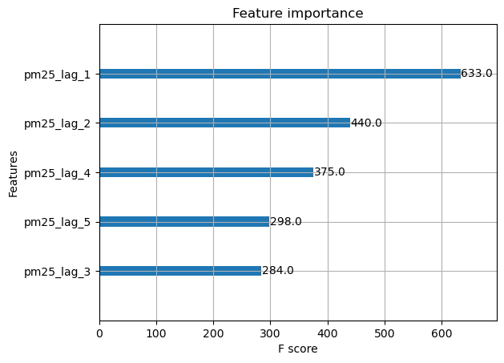

```python
lag_combos = []
for i in range(1, len(lags_pm) + 1):
    combos = itertools.combinations(lags_pm, i)
    for x in combos:
        lag_combos.append(x)


res = []
for combo in lag_combos:
    df_tmp = df_mod.copy()
    for lag in combo:
        df_tmp[f'pm25_lag_{lag}'] = df_tmp['pm25'].shift(lag)
    df_tmp = df_tmp.dropna()

    train = df_tmp.query('date.dt.year < 2019')
    feats = [f'pm25_lag_{lag}' for lag in combo]
    X_train = train[feats]
    y_train = train['pm25']


    rmse_list, r2_list = cv_by_year(X_train, y_train)
    res.append({
        'lags': combo,
        'rmse_list': round(sum(rmse_list) / len(rmse_list), 3),
        'r2_list': round(sum(r2_list) / len(r2_list), 3)
    })

res = sorted(res, key=lambda x: x['rmse_list'])
for i in res:
    print(f"Lags: {i['lags']} | CV Avg. RMSE: {i['rmse_list']} | CV Avg. R²: {i['r2_list']}")

df_all = df_mod.copy()
for i in lags_pm:
    df_all[f'pm25_lag_{i}'] = df_all['pm25'].shift(i)
df_all = df_all.dropna()

train_all = df_all.query('date.dt.year < 2019')
feats_all = [f'pm25_lag_{i}' for i in lags_pm]

X_all = train_all[feats_all]
y_all = train_all['pm25']

full_model_3 = xgb.XGBRegressor(n_estimators=300, learning_rate=0.03, max_depth=3, random_state=0)
full_model_3.fit(X_all, y_all)
xgb.plot_importance(full_model_3)
```

Our R² with only lagged PM2.5 as a feature is 0.322, close to our previous model's 0.425. This confirms that there is more predictive power in lagged PM2.5 as a feature than lagged temperature and precipitation, but that the latter features still add value to the model.

We are essentially left with two models:

1. A model using only lagged temperature and precipitation (R² = 0.121)
2. A model incorporating lagged temperature, precipitation, and PM2.5 (R² = 0.425)

Model 1 can be used to model PM2.5 long-term, but its very weak predictive strength prevents much practical use. However, it reveals a relationship between lagged temperature/precipitation and PM2.5, specifically that 1-day lagged temperature is the most significant predictors, aside from lagged PM2.5, and that temperature features, even with lags, are typically more indicative of PM2.5 values than precipitation features. (Basic correlation tests hinted at this, but not as conclusively.) Model 2 may have more practical use due to its stronger R², which indicates the supremacy of lagged PM2.5 as a predictor. However, because it requires PM2.5 values from earlier in the week, it can only be used for short-term forecasting, such as modeling the following day's PM2.5.

In reality, PM2.5 levels are influenced by many additional factors, such as wind speed, humidity, and atmospheric pressure. Incorporating these variables could further improve our model’s accuracy and allow it to generalize more efficiently. Further research could also investigate the relationship between our features and target variables across different regions in South Korea, as the eastern region of Cheongnim-dong was previously observed to have stronger relationships between climate and PM2.5 than the western Gwanak-gu.

```python
#!jupyter nbconvert --to html --no-input WGU_Capstone_Bonin.ipynb --log-level=ERROR
```